# Comparing patterns of gene expression: tumor v. normal colon tissue

Gail Hobbs

April 5, 2020

# FWER (Holm) and FDR (Benjamini–Yekutieli)

One method for identifying differentially expressed genes is to perform a two-sided Student t-test for each gene comparing the two groups, which is what is done in the corresponding paper:

[Broad patterns of gene expression revealed by clustering analysis of tumor and normal colon tissues probed by oligonucleotide arrays (Alon 1999)](https://www.pnas.org/content/96/12/6745.full)

First, we run a multiple t-test on the data, and again with respect to FWER and FDR.

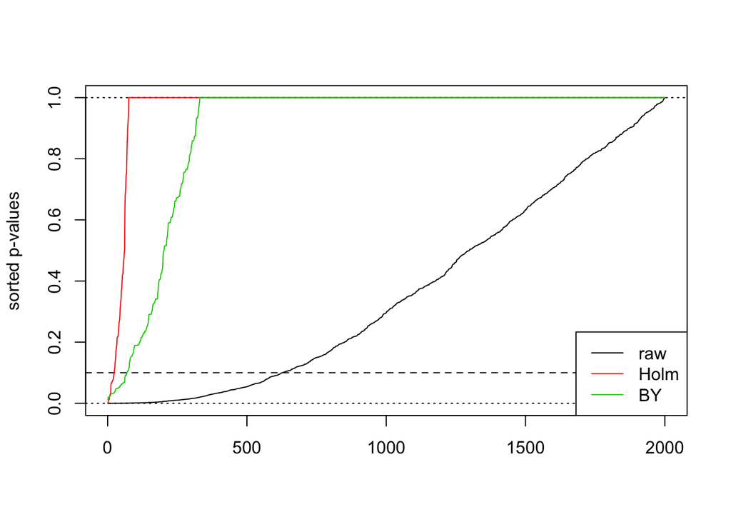

```r
multiple.t.test <- function(A, grp_labels, c = "none") {
  rownames(A) <- grp_labels
  m = ncol(A)
  pval = numeric(m)
  ind = as.integer(grp_labels)

  for (i in 1:m) {
   tumor = A[(ind == 1), i]
   normal = A[(ind == 2), i]
   pval[i] = t.test(tumor, normal)$p.value
  }

  pval.corrected = p.adjust(pval, c)
  return(pval.corrected)
}

dat = load("alon1999.rda")
expression_data = gene_expression$expression
labels = gene_expression$status

pval = multiple.t.test(expression_data, labels) # raw
pval.holm = multiple.t.test(expression_data, labels, "holm")  # FWER
pval.by = multiple.t.test(expression_data, labels, "BY") # FDR

plot(sort(pval),
     type = "l",
     xlab = "",
     ylab = "sorted p-values")
abline(h = 0.10, lty = 2) # 0.10 level
abline(h = 0, lty = 3)
abline(h = 1, lty = 3)
lines(sort(pval.holm), type = "l", col = 2)
lines(sort(pval.by), type = "l", col = 3)
legend("bottomright",
       c("raw", "Holm", "BY"),
       col = 1:3, lty = 1, bg = "white")
```

Rejections at the 10% level, 10% FWER, and 10% FDR, respectively:

```r
sum(pval <= 0.10)
```

```
[1] 627
```

```r
sum(pval.holm <= 0.10)
```

```
[1] 23
```

```r
sum(pval.by <= 0.10)
```

```
[1] 69
```

Running a multiple t-test on the data without adjustment at a 10% level, we reject 627 null hypotheses. Given the size of this dataset, we would like to reduce our considerations much further; 627/2000 is too large (30% of dataset). Therefore, a p-value adjustment is recommended. We can see that controlling the FWER at 10% with the Holm method results in the smallest number of rejections, less than half of the rejections from controlling the FDR with the Benjamini–Yekutieli’s (BY) method.

Controlling FWER signifcantly narrows our pool of genes to study for differences in cancerous vs. noncancerous tissue.

# Association between gene expression levels

## Normal

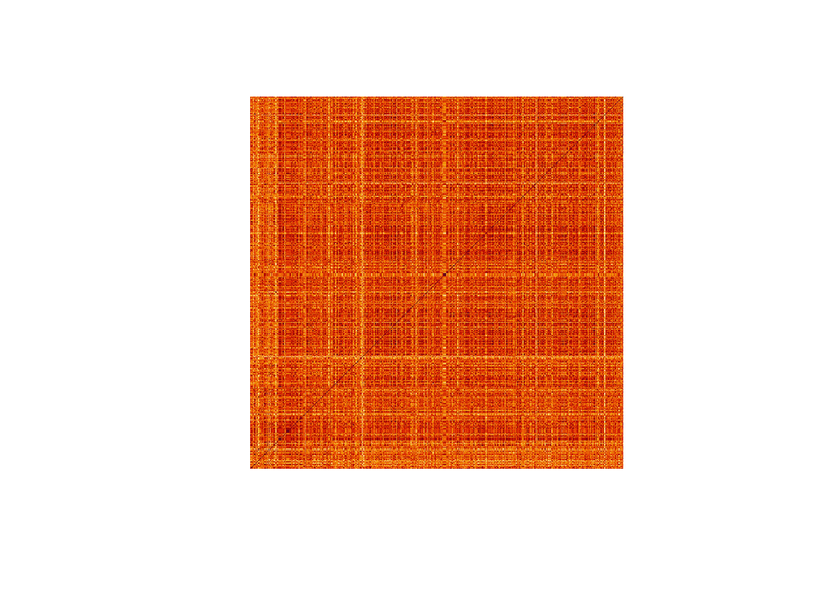

```r
m = nrow(expression_data)
n = ncol(expression_data)

expression_data.normal = expression_data[(labels == "normal"), ]
spearman.normal = cor(expression_data.normal, method = "spearman")
image(spearman.normal[1:500, 1:500], axes = FALSE, asp = 1)
```

## Tumor

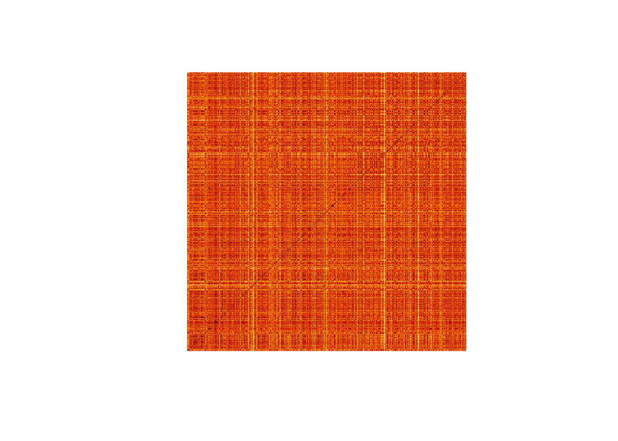

```r
expression_data.tumor = expression_data[(labels == "tumor"), ]
spearman.tumor = cor(expression_data.tumor, method = "spearman")
image(spearman.tumor[1:500, 1:500], axes = FALSE, asp = 1)
```

```r
spearman.diff = abs(spearman.normal - spearman.tumor)
which(spearman.diff == max(spearman.diff), arr.ind = TRUE)
```

```
     row col
[1,] 151  91
[2,]  91 151
```

```r
spearman.normal[151, 91]
```

```
[1] -0.4500282
```

```r
spearman.normal[91,151]
```

```
[1] -0.4500282
```

```r
spearman.tumor[151, 91]
```

```
[1] 0.7305816
```

```r
spearman.tumor[91,151]
```

```
[1] 0.7305816
```